# Pierwszy raport

Joanna

# Problem 1

**Utwórz wektor i oblicz sumę:**

- Utwórz wektor zawierający pięć wybranych przez Ciebie liczb z zakresu od 0 do 10.
- Zapisz ten wektor do obiektu.
- Użyj funkcji `sum()` do obliczenia sumy liczb w wektorze.

```r
vec = c(2,4,5,6,7)
sum(vec)
```

```
## [1] 24
```

# Problem 2

**Utwórz ramkę danych:**

- Utwórz ramkę danych zawierającą dwie kolumny.
- Pierwsza kolumna musi zawierać liczby od 1 do 5, a druga kolumna liczby od 6 do 10.
- Pierwsza kolumna musi mieć nazwę “alpha”, a druga kolumna musi mieć nazwę “beta”.
- Nazwij obiekt “my_dat”.
- Wyświetl dane.

**Umieść tutaj swój kod i rozwiązanie:**

```r
my_dat = data.frame(alpha = 1:5, beta = 6:10)
my_dat
```

```
##   alpha beta
## 1     1    6
## 2     2    7
## 3     3    8
## 4     4    9
## 5     5   10
```

# Problem 3

**Użycie funkcji `summary()`:**

- Używając ramki danych utworzonej w Zadaniu 2, użyj polecenia `summary()` aby stworzyć podsumowanie pięciu liczb dla kolumny o nazwie “beta”.

**Umieść tutaj swój kod i rozwiązanie:**

```r
summary(my_dat$beta)
```

```
##    Min. 1st Qu.  Median    Mean 3rd Qu.    Max.
##       6       7       8       8       9      10
```

# Problem 4

**Wykres pudełkowy dochodu rodzinnego:**

- W bloku konfiguracji raportu (wiersz 13) znajduje się kod do importowania przykładowych danych ankietowych, który uruchomi się automatycznie.
- Używając tych danych, utwórz wykres pudełkowy kolumny “Family Income” za pomocą funkcji Base R (nie rysunek utworzony za pomocą `qplot`).
- Umieść swoje imię w tytule wykresu.
- Zmień etykietę osi x na “Family Income”.

**Wskazówka:** Sprawdź książkę kodową, aby zidentyfikować poprawną nazwę kolumny dla pytania o dochód rodziny.

**Umieść tutaj swój kod i rozwiązanie:**

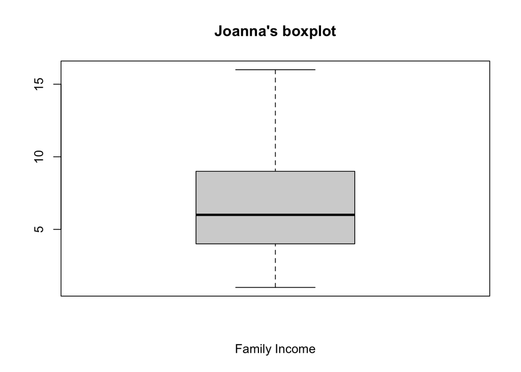

```r
boxplot(dat$faminc_new, main="Joanna's boxplot", xlab="Family Income")
```

# Problem 5

**Filtrowanie danych ankietowych:**

- Używając danych ankietowych, przefiltruj je, aby otrzymać podzbiór zawierający tylko mężczyzn, którzy mieszkają na północnym zachodzie lub środkowym zachodzie Stanów Zjednoczonych, są małżeństwem i identyfikują się jako osoby zainteresowane wiadomościami przez większość czasu.
- Użyj funkcji `str()` aby dostarczyć informacje o uzyskanym zbiorze danych.

**Umieść tutaj swój kod i rozwiązanie:**

```r
# male = 1
# 1 Married
# 2 Midwest 1 Northwest
# 1 Most of the time
men_dat = dat %>% filter(gender == 1, region %in% c(1,2), marstat == 1, newsint == 1)
str(men_dat)
```

```
## 'data.frame':    75 obs. of  25 variables:
##  $ caseid      : int  420208067 412948037 411855595 414480371 416806180 414729651 412021973 412348831 412929385 412047867 ...
##  $ region      : int  2 1 1 1 2 2 1 2 1 2 ...
##  $ gender      : int  1 1 1 1 1 1 1 1 1 1 ...
##  $ educ        : int  3 5 6 5 3 2 6 5 5 5 ...
##  $ edloan      : int  2 1 2 1 1 2 2 2 2 2 ...
##  $ race        : int  1 1 1 1 1 1 1 1 1 1 ...
##  $ hispanic    : int  2 2 2 2 2 2 2 2 2 2 ...
##  $ employ      : int  1 1 1 1 1 5 5 1 1 1 ...
##  $ marstat     : int  1 1 1 1 1 1 1 1 1 1 ...
##  $ pid7        : int  4 1 4 4 6 2 1 1 1 7 ...
##  $ ideo5       : int  5 1 3 3 3 1 2 3 1 5 ...
##  $ pew_religimp: int  4 4 4 1 2 4 4 2 4 1 ...
##  $ newsint     : int  1 1 1 1 1 1 1 1 1 1 ...
##  $ faminc_new  : int  10 11 10 9 10 2 13 8 7 11 ...
##  $ union       : int  1 2 3 3 1 3 2 2 2 3 ...
##  $ investor    : int  2 1 1 1 1 2 1 2 1 2 ...
##  $ CC18_308a   : int  4 4 4 1 2 3 4 4 4 1 ...
##  $ CC18_310a   : int  2 3 3 3 2 2 3 2 3 2 ...
##  $ CC18_310b   : int  2 3 3 3 2 3 3 5 3 3 ...
##  $ CC18_310c   : int  3 3 3 3 3 3 2 5 3 3 ...
##  $ CC18_310d   : int  2 5 3 3 3 2 2 2 3 3 ...
##  $ CC18_325a   : int  1 2 1 1 1 2 2 2 2 1 ...
##  $ CC18_325b   : int  2 2 1 1 1 1 2 1 2 2 ...
##  $ CC18_325c   : int  1 2 2 1 1 2 2 1 2 2 ...
##  $ CC18_325d   : int  1 1 1 1 1 1 1 1 2 1 ...
```

# Problem 6

**Filtrowanie danych i tabela częstotliwości:**

- Przefiltruj dane tak samo jak w problemie 5.
- Użyj funkcji R, aby utworzyć tabelę częstotliwości odpowiedzi na pytanie, czy respondenci ankiety inwestują na giełdzie.

**Umieść tutaj swój kod i rozwiązanie:**

```r
#  1 Yes
table(men_dat$investor)
```

```
##
##  1  2
## 57 18
```

# Problem 7

**Tworzenie nowej kolumny “tax_scale”:**

- Wracając do użycia wszystkich wierszy w zbiorze danych, utwórz nową kolumnę w danych za pomocą `mutate`, która będzie równa 0, 1 lub 2, aby odzwierciedlić, czy respondent popiera podniesienie standardowej ulgi podatkowej z 12 000 do 25 000, popiera obniżenie stawki podatku dochodowego od osób prawnych z 39 do 21 procent, czy oba te działania (czyli poparcie dla żadnej z polityk równe 0, poparcie dla jednej z dwóch polityk równe 1, a poparcie dla obu polityk równe 2).
- Nazwij kolumnę “tax_scale”.
- **Wskazówka:** Będziesz musiał użyć także funkcji `recode()`.
- Wyświetl pierwsze dwadzieścia elementów nowo utworzonej kolumny.

**Umieść tutaj swój kod i rozwiązanie:**

```r
# tax 39 to 20 -> 1 Support
# taxes increase -> 1 Support
dat = dat %>% mutate(tax_scale = recode(CC18_325c, '1'=1, '2'=0) + recode(CC18_325a, '1'=1, '2'=0))
head(dat$tax_scale,20)
```

```
##  [1] 2 0 2 0 2 2 2 0 1 0 0 2 0 0 0 1 0 1 1 0
```

# Problem 8

**Tabela częstotliwości dla “tax_scale”:**

- Użyj polecenia tabeli częstotliwości, aby pokazać, ile jest 0, 1 i 2 w kolumnie utworzonej w Zadaniu 7.

**Umieść tutaj swój kod i rozwiązanie:**

```r
table(dat$tax_scale)
```

```
##
##   0   1   2
## 286 336 247
```

# Problem 9

**Obliczanie średniej aprobaty dla Prezydenta Trumpa według regionów:**

- Ponownie, używając wszystkich wierszy oryginalnego zbioru danych, użyj `summarise` i `group_by`, aby obliczyć średnią (średnią arytmetyczną) aprobatę dla pracy Prezydenta Trumpa w każdym z czterech regionów wymienionych w kolumnie “region”.

**Umieść tutaj swój kod i rozwiązanie:**

```r
dat %>% group_by(region) %>% summarise(mean = mean(CC18_308a))
```

```
## # A tibble: 4 × 2
##   region  mean
##    <int> <dbl>
## 1      1  2.77
## 2      2  2.76
## 3      3  2.71
## 4      4  3.03
```

# Problem 10

**Tabela podsumowująca dla nie-inwestorów z określonym dochodem:**

- Ponownie, zacznij od wszystkich wierszy oryginalnego zbioru danych, użyj `summarise()`, aby utworzyć tabelę podsumowującą dla respondentów ankiety, którzy nie są inwestorami i których roczny dochód rodzinny wynosi od 40 000 do 119 999 dolarów rocznie.
- Tabela powinna zawierać średnią, medianę i odchylenie standardowe dla kolumny dotyczącej ważności religii.

**Umieść tutaj swój kod i rozwiązanie:**

```r
#  2 No
# 5 $40,000 - $49,999
# 6 $50,000 - $59,999
# 7 $60,000 - $69,999
# 8 $70,000 - $79,999
# 9 $80,000 - $99,999
# 10 $100,000 - $119,999
dat %>% filter(investor==2, faminc_new %in% c(5:10)) %>% summarise(
  MeanReligionImp = mean(pew_religimp),
  MedianReligionImp= median(pew_religimp),
  StandardDevReligionImp = sd(pew_religimp)
)
```

```
##   MeanReligionImp MedianReligionImp StandardDevReligionImp
## 1        2.325893                 2               1.188906
```

# Problem 11

**Tabela z kable() i summarise():**

- Użyj `kable()` i funkcji `summarise()`, aby utworzyć tabelę z jednym wierszem i trzema kolumnami, która zawiera średnią, medianę i odchylenie standardowe dla kolumny o nazwie `faminc_new` w danych ankietowych.

**Umieść tutaj swój kod i rozwiązanie:**

```r
dat %>% summarise(Mean = mean(faminc_new, na.rm= TRUE),
                      Median= median(faminc_new),
                      Std.Dev. = sd(faminc_new)) %>% kable()
```

| Mean | Median | Std.Dev. |
| --- | --- | --- |
| 6.581128 | 6 | 3.247035 |

# Problem 12

**Histogram identyfikacji partyjnej (pid7):**

- Używając danych ankietowych, użyj `qplot()` do utworzenia histogramu kolumny o nazwie `pid7`.
- Zmień etykietę osi x na “Siedmiopunktowa Identyfikacja Partyjna”, a etykietę osi y na “Liczba”.

**Uwaga:** Możesz zignorować komunikat “stat_bin()”, który generuje R podczas rysowania tego wykresu. Konfiguracja bloku kodu spowoduje pominięcie tego komunikatu.

**Umieść tutaj swój kod i rozwiązanie:**

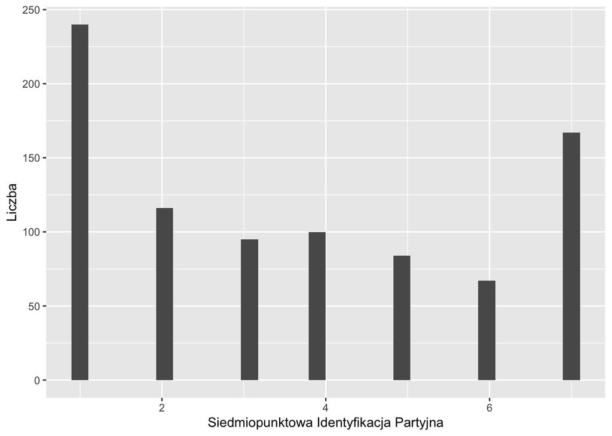

```r
qplot(data = dat, x = pid7, xlab = "Siedmiopunktowa Identyfikacja Partyjna", ylab = "Liczba")
```